# Statistical Learning HW6 实战

Ding Zepeng,18307110088

2020/11/25

# 1 1. 读入数据：

```r
rm(list=ls())
data1 <- read.csv("simudata.csv", header = T)
head(data1)
```

|  | creded | debitF | meanpay | billnum | debitM | zhongxingM | sidaM | xindaiR | cardnum | xindaiF | maxpay | zhuanzhangF | gongjiaoF | zhuanzhangR | age | gongjiaoR | sidaF | sidaR | zhongxingF | zhongxingR | xiaofeiF | jinkaF | zhuanzhangM | gongjiaoM | youxiM | xindaiS | black |
| --- | --- | --- | --- | --- | --- | --- | --- | --- | --- | --- | --- | --- | --- | --- | --- | --- | --- | --- | --- | --- | --- | --- | --- | --- | --- | --- | --- |
| 1 | 0.02 | 28 | 474795 | 4 | 784137.54 | 56826 | 307042 | 365.00 | 2 | 6 | 1665922.93 | 69 | 0 | 359.61 | 26 | 349.43 | 7 | 7.83 | 4 | 334.38 | 6 | 9 | 508646.0 | 297.83 | 66.02 | 5760.22 | 1 |
| 2 | 0.16 | 2 | 346573 | 32 | 1217.43 | 43644 | 15096 | 311.73 | 9 | 0 | 9781.23 | 2 | 2 | 95.68 | 29 | 365.00 | 4 | 91.77 | 14 | 365.00 | 1 | 11 | 425876.2 | 3521.03 | 22.75 | 83872.62 | 1 |
| 3 | 0.32 | 56 | 168844 | 191 | 95001.76 | 279217 | 69815 | 42.32 | 8 | 0 | 4448852.49 | 33 | 1 | 230.09 | 30 | 365.00 | 64 | 36.05 | 10 | 27.08 | 1 | 2 | 492287.8 | 467.64 | 6.66 | 31110.55 | 1 |
| 4 | 0.01 | 28 | 69002 | 89 | 487782.48 | 273731 | 329437 | 81.60 | 15 | 1 | 8876.84 | 7 | 0 | 267.48 | 30 | 330.19 | 2 | 10.08 | 8 | 191.04 | 1 | 8 | 240067.3 | 288.67 | 119.98 | 7876.13 | 1 |
| 5 | 0.19 | 6 | 408647 | 104 | 22039.56 | 13529 | 24725 | 254.60 | 17 | 9 | 1975116.83 | 1 | 2 | 156.96 | 29 | 324.66 | 11 | 324.21 | 23 | 248.39 | 7 | 0 | 455464.5 | 11834.25 | 28.97 | 13765.38 | 0 |
| 6 | 0.20 | 65 | 285313 | 3 | 194798.70 | 11285 | 17961 | 50.31 | 5 | 0 | 2278266.73 | 17 | 1 | 144.48 | 24 | 365.00 | 6 | 237.08 | 0 | 361.47 | 4 | 0 | 192392.7 | 527.81 | 27.45 | 161711.43 | 0 |

# 2 2. 按要求绘制对比箱线图，并进行分析：

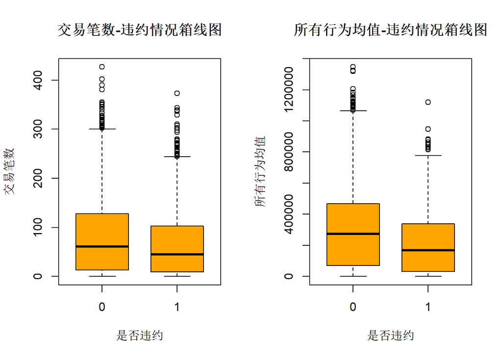

```r
par(mfrow = c(1,2))
## 根据交易笔数绘制违约组和非违约组的对比箱线图
boxplot(data1$billnum ~ data1$black, xlab = "是否违约", ylab = "交易笔数", main = "交易笔数-违约情况箱线图", col = 'orange',boxwex = 0.7)

## 根据用户所有行为均值绘制违约组和非违约组的对比箱线图
boxplot(data1$meanpay ~ data1$black, xlab = "是否违约", ylab = "所有行为均值", main = "所有行为均值-违约情况箱线图", col = 'orange',boxwex = 0.7)
```

- 解读：由箱线图可以看出，整体而言违约用户的交易笔数小于未违约用户（无论是从中位数，还是四分位数意义上都小于），且违约用户的交易笔数波动幅度略小于未违约用户；违约用户所有交易行为花费的**平均金额**整体上也比未违约用户少，波动幅度也较小。
- 这与实际生活经验较为吻合，往往在某平台交易不活跃（交易笔数少）、花费平均金额少的用户更容易违约，而交易活跃、花费金额大的用户**相对不容易**违约，因为其违约带来的代价更大（或者换一种角度来看，交易活跃、花费金额较大说明该用户经济水平较高，完全有能力不违约/没必要违约）。

# 3 3. 按要求划分训练集、测试集并进行决策树建模；绘制ROC曲线

```r
set.seed(1234)
# 7:3划分训练集和测试集
sub <- sample(1:nrow(data1),round(nrow(data1)*0.7))
traindata <- data1[sub,]   #取0.7的数据做训练集
testdata <- data1[-sub,]   #取0.3的数据做测试集

# 用rpart包的rpart函数构建决策树模型，用默认参数
library(rpart)
dtree<-rpart(black ~ ., data = traindata)
printcp(dtree)
```

```
##
## Regression tree:
## rpart(formula = black ~ ., data = traindata)
##
## Variables actually used in tree construction:
## [1] creded      meanpay     xindaiR     zhuanzhangF
##
## Root node error: 1246.7/5622 = 0.22175
##
## n= 5622
##
##         CP nsplit rel error  xerror      xstd
## 1 0.033162      0   1.00000 1.00023 0.0095239
## 2 0.026577      1   0.96684 0.98023 0.0101259
## 3 0.016145      2   0.94026 0.97132 0.0106368
## 4 0.010334      3   0.92412 0.94298 0.0109339
## 5 0.010081      4   0.91378 0.93814 0.0111854
## 6 0.010000      5   0.90370 0.93834 0.0111881
```

```r
# 在测试集上测试
predval <- as.numeric(predict(dtree, newdata = testdata))
mean(predval)
```

```
## [1] 0.3317272
```

```r
# ROC曲线与AUC值
library(pROC)
roc1 <- roc(testdata$black, predval)  # 构建roc对象
```

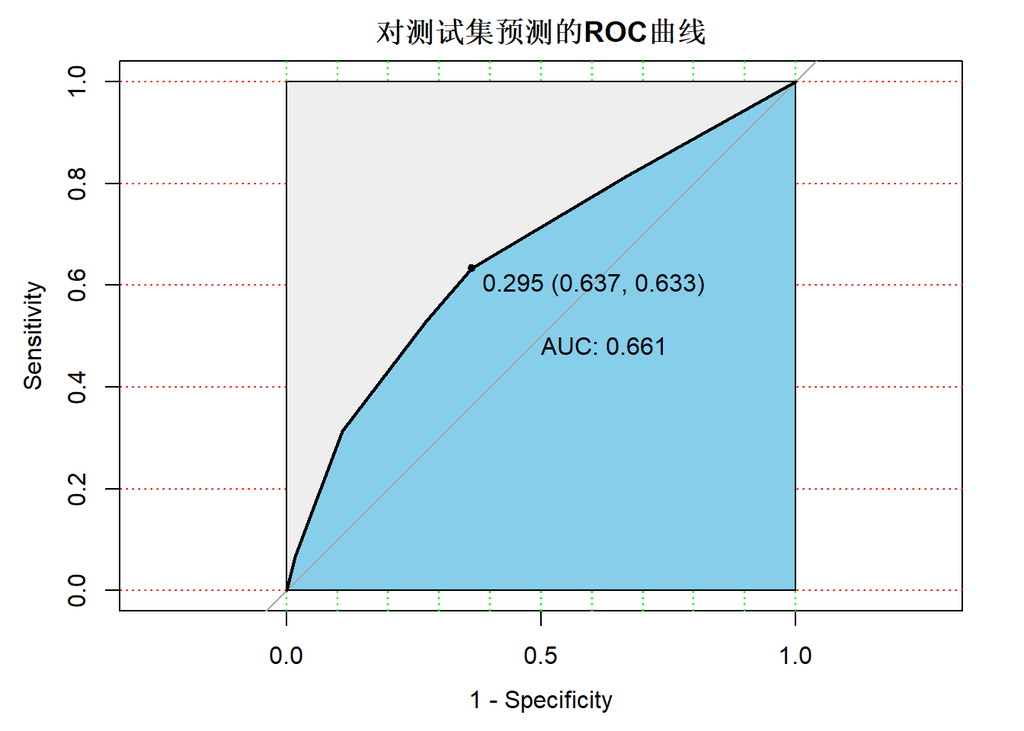

```r
plot(roc1, print.auc=TRUE, main="对测试集预测的ROC曲线", auc.polygon=TRUE, grid=c(0.1, 0.2),
     grid.col=c("green", "red"), max.auc.polygon=TRUE,
     auc.polygon.col="skyblue", print.thres=TRUE, legacy.axes = T)        #画出ROC曲线，标出坐标，并标出AUC的值
```

- 分析：由ROC曲线及AUC值可以看出，由训练集用rpart函数得出的决策树（默认参数，此时method=“anova”），在测试集上预测结果的的AUC值仅0.661，预测效果一般，但优于随机分类器（AUC=0.5）；
- 尝试修改rpart函数的参数为method=“class”画出分类树，但AUC更低，为0.613；篇幅原因（且题目要求用默认参数而非method=“class”）此处不展开。

# 4 4. 画决策树图形并解读

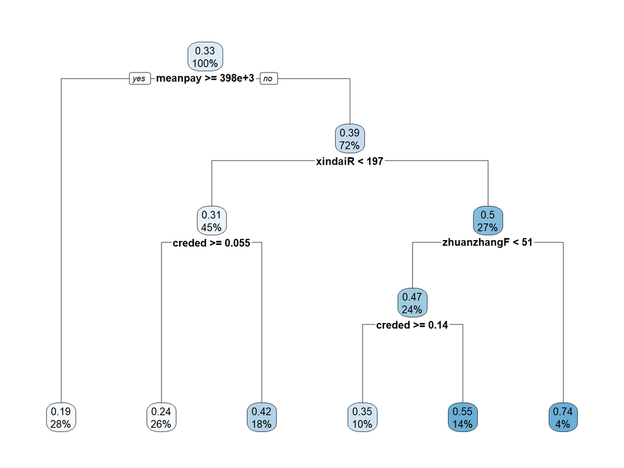

```r
library(rpart.plot)
rpart.plot(dtree,branch=1,type=2, fallen.leaves=T,cex=0.8)
```